# Multiple Regression & Generalized Linear Models (GLMs)

EA30 / marc

2026-04-09

# 1 Welcome

This tutorial introduces **multiple regression** and **generalized linear models (GLMs)** in R. These tools allow you to model relationships between a response variable and **multiple predictors**, test **interactions**, compare models using **AIC**, and analyze **count** and **binary** data.

By the end of this tutorial, you will be able to:

- Fit multiple linear regression models
- Interpret coefficients with multiple predictors
- Specify and interpret interaction terms
- Compare models using AIC
- Fit GLMs for **count** (Poisson) and **binary** (logistic) data

# 2 Setup

```r
# Load required packages
library(tidyverse)
```

# 3 Part 1: Multiple Linear Regression

## 3.1 Example Data

We will use the built-in `mtcars` dataset.

```r
data(mtcars)
head(mtcars)
```

```
##                    mpg cyl disp  hp drat    wt  qsec vs am gear carb
## Mazda RX4         21.0   6  160 110 3.90 2.620 16.46  0  1    4    4
## Mazda RX4 Wag     21.0   6  160 110 3.90 2.875 17.02  0  1    4    4
## Datsun 710        22.8   4  108  93 3.85 2.320 18.61  1  1    4    1
## Hornet 4 Drive    21.4   6  258 110 3.08 3.215 19.44  1  0    3    1
## Hornet Sportabout 18.7   8  360 175 3.15 3.440 17.02  0  0    3    2
## Valiant           18.1   6  225 105 2.76 3.460 20.22  1  0    3    1
```

Suppose we want to predict **fuel efficiency (`mpg`)** using:

- Car weight (`wt`)
- Horsepower (`hp`)

## 3.2 Fitting a Multiple Regression Model

```r
model1 <- lm(mpg ~ wt + hp, data = mtcars)
summary(model1)
```

```
##
## Call:
## lm(formula = mpg ~ wt + hp, data = mtcars)
##
## Residuals:
##    Min     1Q Median     3Q    Max
## -3.941 -1.600 -0.182  1.050  5.854
##
## Coefficients:
##             Estimate Std. Error t value Pr(>|t|)
## (Intercept) 37.22727    1.59879  23.285  < 2e-16 ***
## wt          -3.87783    0.63273  -6.129 1.12e-06 ***
## hp          -0.03177    0.00903  -3.519  0.00145 **
## ---
## Signif. codes:  0 '***' 0.001 '**' 0.01 '*' 0.05 '.' 0.1 ' ' 1
##
## Residual standard error: 2.593 on 29 degrees of freedom
## Multiple R-squared:  0.8268, Adjusted R-squared:  0.8148
## F-statistic: 69.21 on 2 and 29 DF,  p-value: 9.109e-12
```

### 3.2.1 Interpretation

- Each coefficient represents the effect of a predictor **holding the others constant**
- The intercept is the predicted `mpg` when all predictors are zero (often not meaningful)

## 3.3 Visualizing Partial Relationships

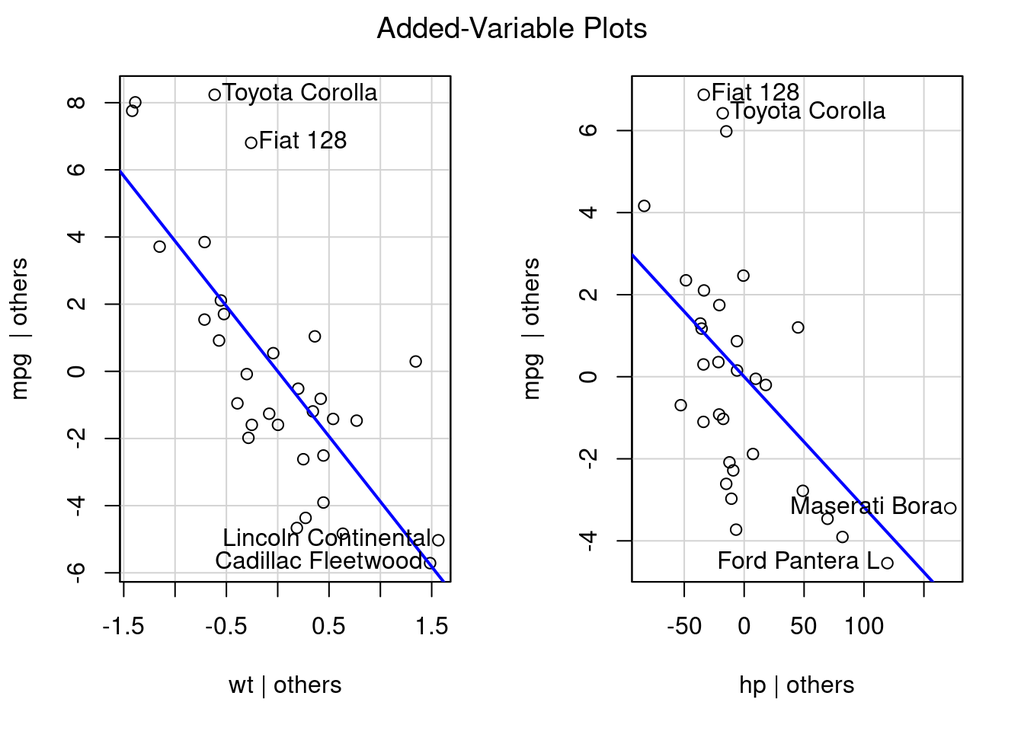

```r
# Added-variable (partial regression) plot
library(car)
avPlots(model1)
```

# 4 Part 2: Interaction Terms

Sometimes the effect of one predictor depends on another.

Example: Does the effect of **weight** on `mpg` depend on **horsepower**?

```r
model2 <- lm(mpg ~ wt * hp, data = mtcars)
summary(model2)
```

```
##
## Call:
## lm(formula = mpg ~ wt * hp, data = mtcars)
##
## Residuals:
##     Min      1Q  Median      3Q     Max
## -3.0632 -1.6491 -0.7362  1.4211  4.5513
##
## Coefficients:
##             Estimate Std. Error t value Pr(>|t|)
## (Intercept) 49.80842    3.60516  13.816 5.01e-14 ***
## wt          -8.21662    1.26971  -6.471 5.20e-07 ***
## hp          -0.12010    0.02470  -4.863 4.04e-05 ***
## wt:hp        0.02785    0.00742   3.753 0.000811 ***
## ---
## Signif. codes:  0 '***' 0.001 '**' 0.01 '*' 0.05 '.' 0.1 ' ' 1
##
## Residual standard error: 2.153 on 28 degrees of freedom
## Multiple R-squared:  0.8848, Adjusted R-squared:  0.8724
## F-statistic: 71.66 on 3 and 28 DF,  p-value: 2.981e-13
```

### 4.0.1 Reading an Interaction

- `wt:hp` represents how the slope of `wt` changes with `hp`
- Interaction models should usually include the main effects

## 4.1 Plotting an Interaction

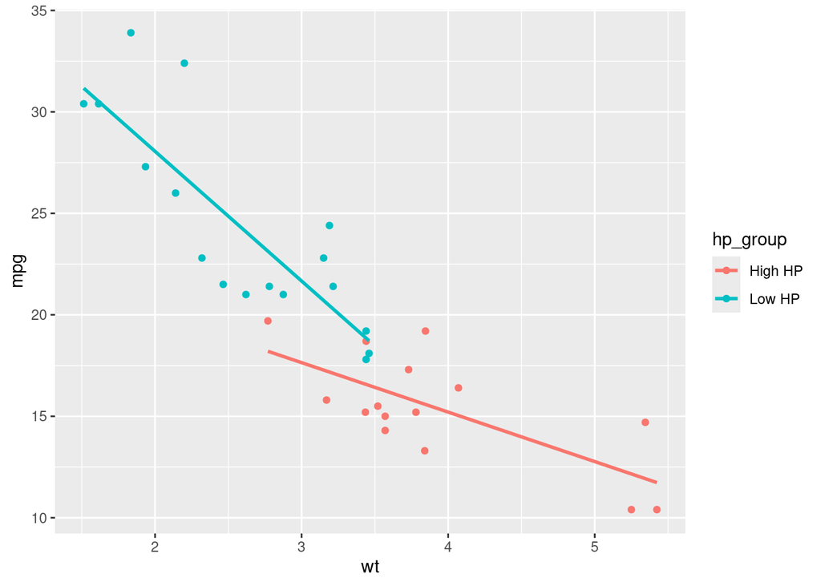

```r
mtcars %>%
  mutate(hp_group = if_else(hp > median(hp), "High HP", "Low HP")) %>%
  ggplot(aes(wt, mpg, color = hp_group)) +
  geom_point() +
  geom_smooth(method = "lm", se = FALSE)
```

# 5 Part 3: Model Selection with AIC

AIC (Akaike Information Criterion) balances **model fit** and **complexity**.

Lower AIC is better.

```r
model_simple <- lm(mpg ~ wt, data = mtcars)
model_full   <- lm(mpg ~ wt + hp + cyl, data = mtcars)

AIC(model_simple, model_full, model1, model2)
```

```
##              df      AIC
## model_simple  3 166.0294
## model_full    5 155.4766
## model1        4 156.6523
## model2        5 145.6109
```

### 5.0.1 Rules of Thumb

- ΔAIC < 2 → models are similarly supported
- Prefer simpler models when AICs are close

# 6 Part 4: Generalized Linear Models (GLMs)

Linear regression assumes:

- Normally distributed errors
- Constant variance

GLMs allow different **distributions** and **link functions**.

## 6.1 GLM for Count Data (Poisson Regression)

### 6.1.1 Example

Suppose we count events (e.g., number of species).

```r
# Simulated count data
set.seed(42)
df_count <- tibble(
  x = runif(50, 0, 10),
  count = rpois(50, lambda = exp(1 + 0.3 * x))
)
```

```r
poisson_model <- glm(count ~ x, family = poisson, data = df_count)
summary(poisson_model)
```

```
##
## Call:
## glm(formula = count ~ x, family = poisson, data = df_count)
##
## Coefficients:
##             Estimate Std. Error z value Pr(>|z|)
## (Intercept)  0.89466    0.12032   7.436 1.04e-13 ***
## x            0.31329    0.01449  21.623  < 2e-16 ***
## ---
## Signif. codes:  0 '***' 0.001 '**' 0.01 '*' 0.05 '.' 0.1 ' ' 1
##
## (Dispersion parameter for poisson family taken to be 1)
##
##     Null deviance: 685.241  on 49  degrees of freedom
## Residual deviance:  37.871  on 48  degrees of freedom
## AIC: 270.93
##
## Number of Fisher Scoring iterations: 4
```

### 6.1.2 Interpretation

- Coefficients are on the **log scale**
- `exp(coef)` gives multiplicative effects

```r
exp(coef(poisson_model))
```

```
## (Intercept)           x
##    2.446504    1.367918
```

## 6.2 Checking Fit

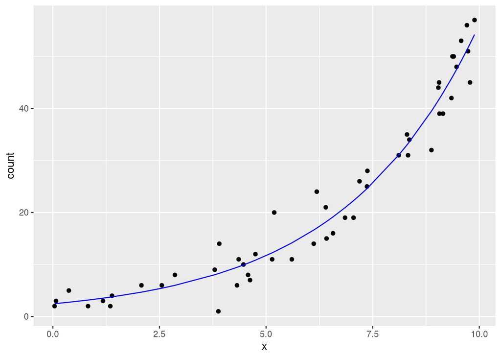

```r
# Plot observed vs predicted
df_count$predicted <- predict(poisson_model, type = "response")

ggplot(df_count, aes(x, count)) +
  geom_point() +
  geom_line(aes(y = predicted), color = "blue")
```

# 7 Part 5: GLM for Binary Data (Logistic Regression)

### 7.0.1 Example

Binary outcomes (yes/no, presence/absence).

```r
# Simulated binary data
set.seed(123)
df_binary <- tibble(
  x = rnorm(100),
  y = rbinom(100, 1, plogis(-0.5 + 1.2 * x))
)
```

```r
logit_model <- glm(y ~ x, family = binomial, data = df_binary)
summary(logit_model)
```

```
##
## Call:
## glm(formula = y ~ x, family = binomial, data = df_binary)
##
## Coefficients:
##             Estimate Std. Error z value Pr(>|z|)
## (Intercept)  -0.3097     0.2296  -1.349    0.177
## x             1.2663     0.3080   4.111 3.94e-05 ***
## ---
## Signif. codes:  0 '***' 0.001 '**' 0.01 '*' 0.05 '.' 0.1 ' ' 1
##
## (Dispersion parameter for binomial family taken to be 1)
##
##     Null deviance: 137.99  on 99  degrees of freedom
## Residual deviance: 114.76  on 98  degrees of freedom
## AIC: 118.76
##
## Number of Fisher Scoring iterations: 4
```

### 7.0.2 Interpretation

- Coefficients are in **log-odds**
- `exp(coef)` gives **odds ratios**

```r
exp(coef(logit_model))
```

```
## (Intercept)           x
##   0.7337018   3.5478259
```

## 7.1 Predicted Probabilities

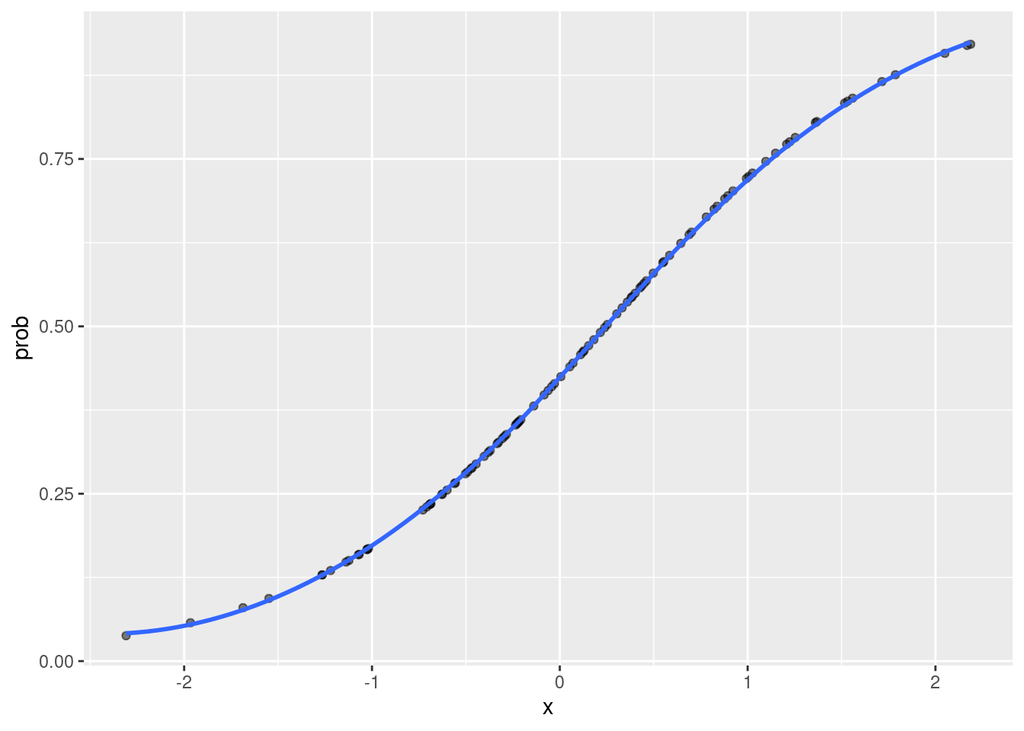

```r
df_binary$prob <- predict(logit_model, type = "response")

ggplot(df_binary, aes(x, prob)) +
  geom_point(alpha = 0.5) +
  geom_smooth(method = "loess")
```

# 8 Model Comparison for GLMs

AIC works for GLMs as well:

```r
logit_null <- glm(y ~ 1, family = binomial, data = df_binary)
AIC(logit_null, logit_model)
```

```
##             df      AIC
## logit_null   1 139.9888
## logit_model  2 118.7598
```

# 9 Key Takeaways ✅

- Multiple regression allows **multiple predictors**
- Interaction terms change how predictors work together
- AIC helps compare non-nested models
- GLMs extend regression to **non-normal data**
- Interpretation depends on the **link function**

# 10 Common Mistakes

- ❌ Ignoring interactions when theoretically important
- ❌ Using linear regression for count or binary data
- ❌ Interpreting GLM coefficients on the raw scale
- ❌ Overfitting complex models with little data

# 11 Congratulations 🎉

You now have the tools to fit and interpret **multiple regression models** and **GLMs**—a major step toward real-world data analysis in environmental and social sciences.